# Practical Machine Learning Project

Mei Sun

January 15, 2017

# Using random forest model to predict human activities from data collected by wearable accelerometers

This is the final project of Coursera Practical Machine Learning course. The purpose of the project is to use a Weight Lifting Exercises Dataset collected with wearable accelerometers to predict the human activities. The WLE dataset includes 5 classes (sitting-down, standing-up, standing, walking, and sitting) collected on 8 hours of activities of 4 healthy subjects. Please see the detail of the dataset at http://groupware.les.inf.puc-rio.br/har and reference.

The specific request for this final project is: “The goal of your project is to predict the manner in which they did the exercise. This is the `classe` variable in the training set. You may use any of the other variables to predict with. You should create a report describing how you built your model, how you used cross validation, what you think the expected out of sample error is, and why you made the choices you did. You will also use your prediction model to predict 20 different test cases.”

## Read and Explore Data

Download data from provided websites.

```r
trainingUrl <- "https://d396qusza40orc.cloudfront.net/predmachlearn/pml-training.csv"
download.file(trainingUrl, destfile = "C:\\Users\\Mei\\Desktop\\practialML\\trainingRaw")
testingUrl <- "https://d396qusza40orc.cloudfront.net/predmachlearn/pml-testing.csv"
download.file(testingUrl, destfile = "C:\\Users\\Mei\\Desktop\\practialML\\testingRaw")
```

Read data.

```r
setwd("C:\\Users\\Mei\\Desktop\\practialML")
trainingRaw <- read.csv(".\\trainingRaw", na.strings = c("NA","","#DIV/0!"))
testingRaw <- read.csv(".\\testingRaw", na.strings = c("NA","","#DIV/0!"))
dim(trainingRaw)
```

```
## [1] 19622   160
```

```r
dim(testingRaw)
```

```
## [1]  20 160
```

## Clean up dataset

Clean up training dataset by removing columns with more than 12000 NAs.

```r
cntgTraining <- which(colSums(is.na(trainingRaw)) > 12000)
trainingCL1 <- trainingRaw[,-c(cntgTraining)]
dim(trainingCL1)
```

```
## [1] 19622    60
```

Remove first column 1-7 (username and date columns that are not useful for creating model) from training set.

```r
trainingCL2 <- trainingCL1[,-c(1:7)]
dim(trainingCL2)
```

```
## [1] 19622    53
```

Clean up testing dataset to keep the same columns (except the last column) as the training dataset.

```r
testingCL1 <- testingRaw[,-c(cntgTraining)]
testingCL2 <- testingCL1[,-c(1:7)]
dim(testingCL2)
```

```
## [1] 20 53
```

```r
names(trainingCL2) %in% names(testingCL2)
```

```
##  [1]  TRUE  TRUE  TRUE  TRUE  TRUE  TRUE  TRUE  TRUE  TRUE  TRUE  TRUE
## [12]  TRUE  TRUE  TRUE  TRUE  TRUE  TRUE  TRUE  TRUE  TRUE  TRUE  TRUE
## [23]  TRUE  TRUE  TRUE  TRUE  TRUE  TRUE  TRUE  TRUE  TRUE  TRUE  TRUE
## [34]  TRUE  TRUE  TRUE  TRUE  TRUE  TRUE  TRUE  TRUE  TRUE  TRUE  TRUE
## [45]  TRUE  TRUE  TRUE  TRUE  TRUE  TRUE  TRUE  TRUE FALSE
```

Except the last column, now the testing dataset has the same columns as the training set.

## Slice training data into training and validating subset data.

```r
library(caret)
set.seed(1227)
inTrain <- createDataPartition(y=trainingCL2$classe, p=0.6, list=FALSE)
myTraining <- trainingCL2[inTrain,]
myTesting <- trainingCL2[-inTrain,]
dim(myTraining)
```

```
## [1] 11776    53
```

```r
dim(myTesting)
```

```
## [1] 7846   53
```

## Covariates validating

```r
nzv <- nearZeroVar(myTraining, saveMetrics=TRUE)
nzv
```

```
##                      freqRatio percentUnique zeroVar   nzv
## roll_belt             1.132597    8.73811141   FALSE FALSE
## pitch_belt            1.017391   13.79925272   FALSE FALSE
## yaw_belt              1.043750   14.44463315   FALSE FALSE
## total_accel_belt      1.071898    0.23777174   FALSE FALSE
## gyros_belt_x          1.114286    1.06148098   FALSE FALSE
## gyros_belt_y          1.129756    0.55197011   FALSE FALSE
## gyros_belt_z          1.057547    1.34171196   FALSE FALSE
## accel_belt_x          1.052061    1.29925272   FALSE FALSE
## accel_belt_y          1.137817    1.13790761   FALSE FALSE
## accel_belt_z          1.061914    2.44565217   FALSE FALSE
## magnet_belt_x         1.184332    2.52207880   FALSE FALSE
## magnet_belt_y         1.034853    2.38620924   FALSE FALSE
## magnet_belt_z         1.013333    3.62601902   FALSE FALSE
## roll_arm             48.404762   19.53125000   FALSE FALSE
## pitch_arm            67.766667   22.50339674   FALSE FALSE
## yaw_arm              31.276923   21.63722826   FALSE FALSE
## total_accel_arm       1.047985    0.56046196   FALSE FALSE
## gyros_arm_x           1.101974    5.23097826   FALSE FALSE
## gyros_arm_y           1.395570    3.04008152   FALSE FALSE
## gyros_arm_z           1.074074    1.89368207   FALSE FALSE
## accel_arm_x           1.137255    6.49626359   FALSE FALSE
## accel_arm_y           1.213115    4.39028533   FALSE FALSE
## accel_arm_z           1.023529    6.38586957   FALSE FALSE
## magnet_arm_x          1.035714   11.08186141   FALSE FALSE
## magnet_arm_y          1.038462    7.20957880   FALSE FALSE
## magnet_arm_z          1.028986   10.52989130   FALSE FALSE
## roll_dumbbell         1.012500   88.12839674   FALSE FALSE
## pitch_dumbbell        2.296296   85.87805707   FALSE FALSE
## yaw_dumbbell          1.191176   87.39809783   FALSE FALSE
## total_accel_dumbbell  1.066586    0.36514946   FALSE FALSE
## gyros_dumbbell_x      1.002717    1.92764946   FALSE FALSE
## gyros_dumbbell_y      1.213889    2.25883152   FALSE FALSE
## gyros_dumbbell_z      1.002755    1.62194293   FALSE FALSE
## accel_dumbbell_x      1.062500    3.39673913   FALSE FALSE
## accel_dumbbell_y      1.028571    3.78736413   FALSE FALSE
## accel_dumbbell_z      1.033557    3.37975543   FALSE FALSE
## magnet_dumbbell_x     1.120000    8.87398098   FALSE FALSE
## magnet_dumbbell_y     1.262626    6.86990489   FALSE FALSE
## magnet_dumbbell_z     1.074766    5.57065217   FALSE FALSE
## roll_forearm         11.782828   14.91168478   FALSE FALSE
## pitch_forearm        58.350000   21.24660326   FALSE FALSE
## yaw_forearm          14.490683   14.30027174   FALSE FALSE
## total_accel_forearm   1.149725    0.56895380   FALSE FALSE
## gyros_forearm_x       1.031153    2.28430707   FALSE FALSE
## gyros_forearm_y       1.072961    6.06317935   FALSE FALSE
## gyros_forearm_z       1.083624    2.36073370   FALSE FALSE
## accel_forearm_x       1.000000    6.53023098   FALSE FALSE
## accel_forearm_y       1.083333    8.24558424   FALSE FALSE
## accel_forearm_z       1.244186    4.64504076   FALSE FALSE
## magnet_forearm_x      1.021739   12.10937500   FALSE FALSE
## magnet_forearm_y      1.176471   15.16644022   FALSE FALSE
## magnet_forearm_z      1.000000   13.29823370   FALSE FALSE
## classe                1.469065    0.04245924   FALSE FALSE
```

There is no zero variance. Keep all the covariates for model creation.

## Data modeling

First try data modeling using prediction tree method.

```r
set.seed(1111)
moddt0 <- train(classe ~., method = "rpart", data=myTraining)
print(moddt0)
```

```
## CART
##
## 11776 samples
##    52 predictor
##     5 classes: 'A', 'B', 'C', 'D', 'E'
##
## No pre-processing
## Resampling: Bootstrapped (25 reps)
## Summary of sample sizes: 11776, 11776, 11776, 11776, 11776, 11776, ...
## Resampling results across tuning parameters:
##
##   cp          Accuracy   Kappa
##   0.02764594  0.5612785  0.43991146
##   0.04074514  0.4483975  0.26804705
##   0.11200759  0.3466748  0.09655492
##
## Accuracy was used to select the optimal model using  the largest value.
## The final value used for the model was cp = 0.02764594.
```

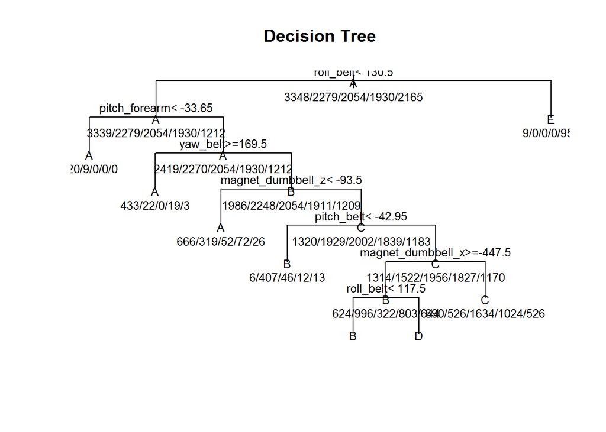

```r
plot(moddt0$finalModel, uniform = TRUE, main = "Decision Tree")
text(moddt0$finalModel, use.n = TRUE, all = TRUE, cex=0.8)
```

```r
dtPred <- predict(moddt0, newdata = myTesting)
confusionMatrix(myTesting$classe, dtPred)$overall[1]
```

```
##  Accuracy
## 0.5593933
```

The estimated model accuracy is only 56% and the out-of-model accuracy is also around 56%. This model is not accurate enough to predict testing samples. Then add pre-processing step for the model fitting.

```r
moddt1 <- train(classe ~., method = "rpart", preProcess = c("center", "scale"),
                data=myTraining)
print(moddt1)
```

```
## CART
##
## 11776 samples
##    52 predictor
##     5 classes: 'A', 'B', 'C', 'D', 'E'
##
## Pre-processing: centered (52), scaled (52)
## Resampling: Bootstrapped (25 reps)
## Summary of sample sizes: 11776, 11776, 11776, 11776, 11776, 11776, ...
## Resampling results across tuning parameters:
##
##   cp          Accuracy   Kappa
##   0.02764594  0.5511245  0.42407945
##   0.04074514  0.4451363  0.25706680
##   0.11200759  0.3292484  0.06726733
##
## Accuracy was used to select the optimal model using  the largest value.
## The final value used for the model was cp = 0.02764594.
```

The accuracy is not improved. Preprocessing with normalizing all predictors does not help with modeling.

Use random forest to build model. `parallel` package is used to improve the performance of random forest in “carret::train” function.

```r
library(parallel)
library(doParallel)
set.seed(2222)
cluster <- makeCluster(detectCores() - 1) # convention to leave 1 core for OS
registerDoParallel(cluster)
fitControl <- trainControl(method = "cv",
                           number = 10,
                           allowParallel = TRUE)
modrf <- train(classe ~., method = "rf", data=myTraining, trControl = fitControl)
stopCluster(cluster)
registerDoSEQ()
```

Evaluate the model on the training dataset. The model accuracy is 100%.

```r
varImp(modrf)
```

```
## rf variable importance
##
##   only 20 most important variables shown (out of 52)
##
##                      Overall
## roll_belt             100.00
## yaw_belt               84.88
## magnet_dumbbell_z      69.70
## magnet_dumbbell_y      66.90
## pitch_forearm          62.87
## pitch_belt             61.82
## magnet_dumbbell_x      52.36
## roll_forearm           47.73
## accel_dumbbell_y       46.11
## accel_belt_z           45.51
## magnet_belt_z          44.57
## roll_dumbbell          43.83
## magnet_belt_y          43.48
## accel_dumbbell_z       37.44
## roll_arm               36.99
## gyros_belt_z           34.35
## accel_forearm_x        34.18
## total_accel_dumbbell   31.11
## yaw_dumbbell           30.41
## accel_dumbbell_x       29.49
```

```r
modrf$finalModel
```

```
##
## Call:
##  randomForest(x = x, y = y, mtry = param$mtry)
##                Type of random forest: classification
##                      Number of trees: 500
## No. of variables tried at each split: 2
##
##         OOB estimate of  error rate: 0.82%
## Confusion matrix:
##      A    B    C    D    E class.error
## A 3342    3    2    0    1 0.001792115
## B   19 2253    7    0    0 0.011408513
## C    0   18 2033    3    0 0.010223953
## D    0    0   36 1893    1 0.019170984
## E    0    0    1    5 2159 0.002771363
```

```r
rfTraningPred <- predict(modrf, newdata = myTraining)
confusionMatrix(rfTraningPred, myTraining$classe)
```

```
## Confusion Matrix and Statistics
##
##           Reference
## Prediction    A    B    C    D    E
##          A 3348    0    0    0    0
##          B    0 2279    0    0    0
##          C    0    0 2054    0    0
##          D    0    0    0 1930    0
##          E    0    0    0    0 2165
##
## Overall Statistics
##
##                Accuracy : 1
##                  95% CI : (0.9997, 1)
##     No Information Rate : 0.2843
##     P-Value [Acc > NIR] : < 2.2e-16
##
##                   Kappa : 1
##  Mcnemar's Test P-Value : NA
##
## Statistics by Class:
##
##                      Class: A Class: B Class: C Class: D Class: E
## Sensitivity            1.0000   1.0000   1.0000   1.0000   1.0000
## Specificity            1.0000   1.0000   1.0000   1.0000   1.0000
## Pos Pred Value         1.0000   1.0000   1.0000   1.0000   1.0000
## Neg Pred Value         1.0000   1.0000   1.0000   1.0000   1.0000
## Prevalence             0.2843   0.1935   0.1744   0.1639   0.1838
## Detection Rate         0.2843   0.1935   0.1744   0.1639   0.1838
## Detection Prevalence   0.2843   0.1935   0.1744   0.1639   0.1838
## Balanced Accuracy      1.0000   1.0000   1.0000   1.0000   1.0000
```

Evaluate the model on the validating dataset.

```r
rfPred <- predict(modrf, newdata = myTesting)
confusionMatrix(rfPred, myTesting$classe)
```

```
## Confusion Matrix and Statistics
##
##           Reference
## Prediction    A    B    C    D    E
##          A 2230    6    0    0    0
##          B    2 1509   23    0    0
##          C    0    3 1344   18    0
##          D    0    0    1 1267    4
##          E    0    0    0    1 1438
##
## Overall Statistics
##
##                Accuracy : 0.9926
##                  95% CI : (0.9905, 0.9944)
##     No Information Rate : 0.2845
##     P-Value [Acc > NIR] : < 2.2e-16
##
##                   Kappa : 0.9906
##  Mcnemar's Test P-Value : NA
##
## Statistics by Class:
##
##                      Class: A Class: B Class: C Class: D Class: E
## Sensitivity            0.9991   0.9941   0.9825   0.9852   0.9972
## Specificity            0.9989   0.9960   0.9968   0.9992   0.9998
## Pos Pred Value         0.9973   0.9837   0.9846   0.9961   0.9993
## Neg Pred Value         0.9996   0.9986   0.9963   0.9971   0.9994
## Prevalence             0.2845   0.1935   0.1744   0.1639   0.1838
## Detection Rate         0.2842   0.1923   0.1713   0.1615   0.1833
## Detection Prevalence   0.2850   0.1955   0.1740   0.1621   0.1834
## Balanced Accuracy      0.9990   0.9951   0.9896   0.9922   0.9985
```

## Use random forest model to predict on the test dataset.

```r
rfPredTesting <- predict(modrf, newdata = testingCL2)
rfPredTesting
```

```
##  [1] B A B A A E D B A A B C B A E E A B B B
## Levels: A B C D E
```

## Conclusion

In this data analysis project, random forest method is used to build a machine learning model to predict the manner of human activity. Total 52 variables are used in this prediction model. The most importance variable is `roll_belt`. The prediction accuracy for this random forest model is 99.26%, much higher than the 56% prediction accuracy for prediction tree model. The expected out of sample error is less than 1%. Therefore the random forest model is the better choice over prediction tree model and it fulfills the entire course requirement.

### Reference

Ugulino, W.; Cardador, D.; Vega, K.; Velloso, E.; Milidiu, R.; Fuks, H. Wearable Computing: Accelerometers’ Data Classification of Body Postures and Movements. Proceedings of 21st Brazilian Symposium on Artificial Intelligence. Advances in Artificial Intelligence - SBIA 2012. In: Lecture Notes in Computer Science. , pp. 52-61. Curitiba, PR: Springer Berlin / Heidelberg, 2012. ISBN 978-3-642-34458-9. DOI: 10.1007/978-3-642-34459-6_6.